# IODS course project

StefanieK

# Introduction to Open Data Science - Course Project

# Chapter 1: About the project

*Write a short description about the course and add a link to your GitHub repository here. This is an R Markdown (.Rmd) file so you should use R Markdown syntax.*

```r
# This is a so-called "R chunk" where you can write R code.

today <- date()
paste("Today is", today, ". Hello R! Hello world!")
```

```
## [1] "Today is Fri Nov 13 00:50:22 2020 . Hello R! Hello world!"
```

### My background and expectations

**How I found out about this course**: I already came across this course last year (unfortunately didn’t have the time to participate) and was already intrigued about the contents and impressed by the fabulous feedback.

**My background and expectations**: As a graduate student in physics I got quite fond of using python for my data analysis work. Now, I am quite excited to see and compare what is possible with R - I am looking forward to participate in this interesting course! So far, the “warming up” week went fine and the introductions were easy to follow. The syntax shown so far didn’t look too complicated and partially familiar to *python* or *python* libraries such as *pandas* and *matplotlib*. As I am quite used to python (and it is more and more used in natural sciences), I don’t expect to switch to *R* after the course, but would love to learn more about it and achieve an understanding of what the pros and cons are. So if something comes up in the future for what *R* is actually more suited, I will be able to use it or – if collaborators use it – able to understand it. And furthermore, it’s always fun to learn new skills.:)

### Practicalities

**Link to my GitHub repository** : https://github.com/kirstef/IODS-project

**Looking forward to next week!**

# Chapter 2: Regression and model validation

*Describe the work you have done this week and summarize your learning.*

- Describe your work and results clearly.
- Assume the reader has an introductory course level understanding of writing and reading R code as well as statistical methods.
- Assume the reader has no previous knowledge of your data or the more advanced methods you are using.

**In this chapter we will explore the dataset from *http://www.helsinki.fi/~kvehkala/JYTmooc/JYTOPKYS3-data.txt*, looking first closer at the dataframe and afterwards visualize some interesting features.**

## Data wrangling

**REMARK: The data wrangling part is done in the .R file in the data-folder. Still, I will show a preview of the original dataset in the diary as it shows the development from the original data to the dataset we finally evaluate.**

### Looking at the original dataset

First let’s read in the full learning2014 data as a dataframe from the given website.

```r
lrn14 <- read.table("http://www.helsinki.fi/~kvehkala/JYTmooc/JYTOPKYS3-data.txt", sep="\t", header=TRUE)
head(lrn14)
```

```
##   Aa Ab Ac Ad Ae Af ST01 SU02 D03 ST04 SU05 D06 D07 SU08 ST09 SU10 D11 ST12
## 1  3  1  2  1  1  1    4    2   4    4    2   4   4    3    3    2   3    3
## 2  2  2  2  2  1  1    4    2   4    4    4   2   3    4    4    1   4    1
## 3  4  1  1  1  1  1    3    1   4    4    2   3   4    1    3    1   4    4
## 4  4  2  3  2  1  1    3    3   4    4    3   4   4    2    3    1   3    3
## 5  3  2  2  1  2  1    4    2   5    3    4   4   4    3    4    2   4    2
## 6  4  2  1  1  1  1    4    3   5    4    3   5   5    4    4    1   5    3
##   SU13 D14 D15 SU16 ST17 SU18 D19 ST20 SU21 D22 D23 SU24 ST25 SU26 D27 ST28
## 1    3   4   3    2    3    2   4    2    3   3   2    2    4    4   4    4
## 2    3   2   3    4    4    2   3    1    2   2   3    4    2    4   2    2
## 3    2   4   2    3    3    1   4    3    2   4   3    3    4    4   3    5
## 4    2   4   3    2    3    1   3    3    3   3   3    2    3    2   3    3
## 5    3   4   3    3    4    1   4    3    2   3   3    4    4    3   3    5
## 6    1   5   4    2    3    2   4    3    4   5   4    2    4    2   5    4
##   SU29 D30 D31 SU32 Ca Cb Cc Cd Ce Cf Cg Ch Da Db Dc Dd De Df Dg Dh Di Dj Age
## 1    3   4   4    3  2  4  3  4  3  2  3  4  3  4  4  5  4  2  4  3  4  4  53
## 2    3   3   4    5  4  4  4  5  5  3  2  4  4  3  3  4  3  2  3  3  2  4  55
## 3    2   4   3    5  3  5  4  4  3  4  4  2  1  4  4  1  4  1  3  1  1  5  49
## 4    3   4   4    3  3  4  4  4  3  4  4  3  2  4  5  2  5  1  5  4  2  5  53
## 5    3   3   4    4  2  4  4  3  3  3  4  4  3  4  4  4  4  2  5  5  3  3  49
## 6    2   5   5    3  3  5  4  4  3  4  5  4  3  5  4  4  4  3  4  3  3  5  38
##   Attitude Points gender
## 1       37     25      F
## 2       31     12      M
## 3       25     24      F
## 4       35     10      M
## 5       37     22      M
## 6       38     21      F
```

Only looking at the head of the dataframe makes it quite visible that some data wrangling will help in understanding the data better. It also shows that meta data is quite valuable as we don’t know by just looking at the variable what their meaning is.

## Data analysis

### Preparing an analysis sub dataset for further data exploration

For this we have to include the library *dplyr* (`library(dplyr)`) which is a common R library used for data wrangling

```r
library(dplyr)
```

### 1. Looking at the new data subset: Reading in the students2014 data

First let’s use `read.csv()` or `read.table()` to read in the data subset created before and saved as a .csv in the project data-subfolder.

```r
students2014 <- read.csv("./data/learning2014.csv", header = TRUE, sep = ",", stringsAsFactors = TRUE)
```

With `head(students2014)` we can display the first six rows of the subset. It is now much better readable and interpretable than before.

```
##   gender age attitude     deep  stra     surf points
## 1      F  53      3.7 3.583333 3.375 2.583333     25
## 2      M  55      3.1 2.916667 2.750 3.166667     12
## 3      F  49      2.5 3.500000 3.625 2.250000     24
## 4      M  53      3.5 3.500000 3.125 2.250000     10
## 5      M  49      3.7 3.666667 3.625 2.833333     22
## 6      F  38      3.8 4.750000 3.625 2.416667     21
```

**Structure and dimension of the subset**

With `dim()` and `str()` we can further explore the dimension and structure of the dataset.

```r
dim(students2014)
```

```
## [1] 183   7
```

```r
str(students2014)
```

```
## 'data.frame':    183 obs. of  7 variables:
##  $ gender  : Factor w/ 2 levels "F","M": 1 2 1 2 2 1 2 1 2 1 ...
##  $ age     : int  53 55 49 53 49 38 50 37 37 42 ...
##  $ attitude: num  3.7 3.1 2.5 3.5 3.7 3.8 3.5 2.9 3.8 2.1 ...
##  $ deep    : num  3.58 2.92 3.5 3.5 3.67 ...
##  $ stra    : num  3.38 2.75 3.62 3.12 3.62 ...
##  $ surf    : num  2.58 3.17 2.25 2.25 2.83 ...
##  $ points  : int  25 12 24 10 22 21 21 31 24 26 ...
```

**Getting rid of 0 values** We can filter our subset further to e.g. exclude the students who didn’t participate in the final exam and look afterwards again at the dimension.

```r
# select rows where points are greater than zero
students2014 <- filter(students2014, points > 0)
dim(students2014)
```

```
## [1] 166   7
```

As one can see we have $183-166=17$ rows with 0 points, so students not taking the final exam. Let’s keep it like this for the further exploration of the data set, as the reasons for not taking the exam are unknown to us and thus don’t necessary have a high relation to the attitude our other variables.

### 2. Visualizations: Graphical overview of the data

Using `ggpairs` gives us a good graphical overview of the data and the correlation of the different variables to each other. Using `col=gender` in the mapping argument let’s us also see gender-differences (color-coded, female(red), male(blueish)).

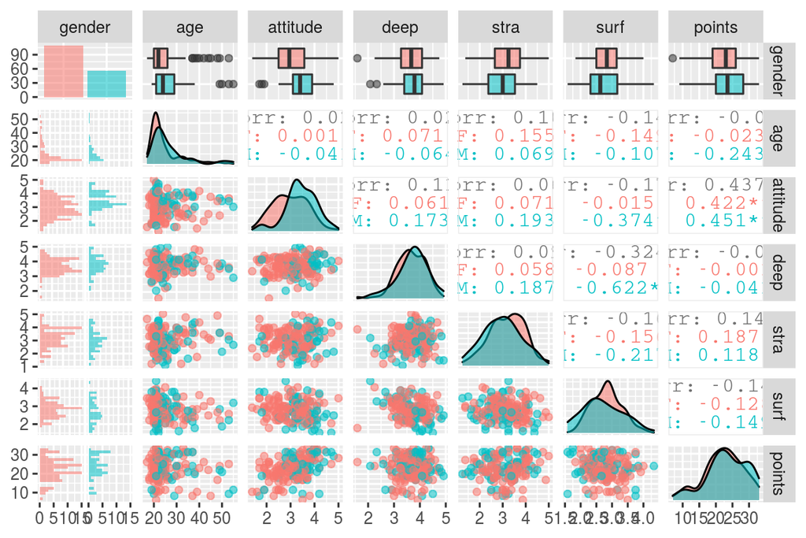

```r
library(ggplot2)
library(GGally)
# create a plot matrix with ggpairs()
ggpairs(students2014, mapping = aes(col = gender, alpha = 0.3), lower = list(combo = wrap("facethist", bins = 20)))
```

Studying the plot in more detail, we see the following parts: scatter plots between the different variables, distributions of the different variables, and correlation values between the different variables. The higher the absolute value of the correlation value, the higher the correlation between the respective variables. As we can seen, the highest correlation seems to be between **points** and **attitude**. Looking at the scatter plot between these two variable we can also see that the data points are roughly scattered along a line, which hints as well at a relation between them. The point distribution for the attitude shows a visible gender difference. Where the distribution for the female students rises to about 2.5 to almost a “plateau” (until 3.5), the distribution for the male students shows only a small fraction of people having the grade 2 or less - after that there is a steep rise to the peak at a bit over 3. The surface question distribution (“surf”) shows a maximum at about 3 for the female students, which is higher than for the male students. For the **age** one can see (as expected) that most of the students are between 20 and 30 years old.

```r
summary(students2014)
```

```
##  gender       age           attitude          deep            stra
##  F:110   Min.   :17.00   Min.   :1.400   Min.   :1.583   Min.   :1.250
##  M: 56   1st Qu.:21.00   1st Qu.:2.600   1st Qu.:3.333   1st Qu.:2.625
##          Median :22.00   Median :3.200   Median :3.667   Median :3.188
##          Mean   :25.51   Mean   :3.143   Mean   :3.680   Mean   :3.121
##          3rd Qu.:27.00   3rd Qu.:3.700   3rd Qu.:4.083   3rd Qu.:3.625
##          Max.   :55.00   Max.   :5.000   Max.   :4.917   Max.   :5.000
##       surf           points
##  Min.   :1.583   Min.   : 7.00
##  1st Qu.:2.417   1st Qu.:19.00
##  Median :2.833   Median :23.00
##  Mean   :2.787   Mean   :22.72
##  3rd Qu.:3.167   3rd Qu.:27.75
##  Max.   :4.333   Max.   :33.00
```

### 3. Regression model

From the pairs plot above let’s choose the points as our target value and the 3 variables with the highest correlation to points as explanatory variables to be used for the regression model: **exam points ~ x1 + x2 + x3**. The respective variables would be *attitude* (corr: 0.437), *stra* (corr: 0.146) and *surf* (corr: -0.140).

`summary(model)` gives us further information on the validity and significance of our model. **Further description and interpretation will still be added.**

```r
# create a regression model with multiple explanatory variables
my_model <- lm(points ~ attitude + stra + surf, data = students2014)
summary(my_model)
```

```
##
## Call:
## lm(formula = points ~ attitude + stra + surf, data = students2014)
##
## Residuals:
##      Min       1Q   Median       3Q      Max
## -17.1550  -3.4346   0.5156   3.6401  10.8952
##
## Coefficients:
##             Estimate Std. Error t value Pr(>|t|)
## (Intercept)  11.0171     3.6837   2.991  0.00322 **
## attitude      3.3952     0.5741   5.913 1.93e-08 ***
## stra          0.8531     0.5416   1.575  0.11716
## surf         -0.5861     0.8014  -0.731  0.46563
## ---
## Signif. codes:  0 '***' 0.001 '**' 0.01 '*' 0.05 '.' 0.1 ' ' 1
##
## Residual standard error: 5.296 on 162 degrees of freedom
## Multiple R-squared:  0.2074, Adjusted R-squared:  0.1927
## F-statistic: 14.13 on 3 and 162 DF,  p-value: 3.156e-08
```

To find more out abouth the significance of the correlations we can look at **t-value** and **Pr(>|t|)**. The understanding of the t-value is here, that it get’s bigger if the Null-Hypothesis is not true. The Null-Hypothesis in this case would be that there is no relation between the variable and the target value. The t-value on its own is difficult to interpret, but **Pr(>|t|)** gives us then the probability for getting the same t-value if the Null-Hypothesis would be true. As one can see, this probability is very low for **attitude**, which is also implied by the *** next to the value, which are described as significance codes in the legend. Thus, a relation between **points** and **attitude** is quite obvious. Both **stra** and **surf** don’t have any significant relation to the target variable, thus I will remove them from the model.

Just for fun once more the model with **attitude** and **stra**:

```r
my_model2 <- lm(points ~ attitude + stra, data = students2014)
summary(my_model2)
```

```
##
## Call:
## lm(formula = points ~ attitude + stra, data = students2014)
##
## Residuals:
##      Min       1Q   Median       3Q      Max
## -17.6436  -3.3113   0.5575   3.7928  10.9295
##
## Coefficients:
##             Estimate Std. Error t value Pr(>|t|)
## (Intercept)   8.9729     2.3959   3.745  0.00025 ***
## attitude      3.4658     0.5652   6.132 6.31e-09 ***
## stra          0.9137     0.5345   1.709  0.08927 .
## ---
## Signif. codes:  0 '***' 0.001 '**' 0.01 '*' 0.05 '.' 0.1 ' ' 1
##
## Residual standard error: 5.289 on 163 degrees of freedom
## Multiple R-squared:  0.2048, Adjusted R-squared:  0.1951
## F-statistic: 20.99 on 2 and 163 DF,  p-value: 7.734e-09
```

The **t-value** is a bit higher and the **Pr(>|t|)** a bit smaller, but still the relation is quite insignificant.

### 4. Reduced regression model: Summary of fitted model

After having also remove the **stra** variable from the model, the model is reduced to the following one:

```r
my_model3 <- lm(points ~ attitude, data = students2014)
summary(my_model3)
```

```
##
## Call:
## lm(formula = points ~ attitude, data = students2014)
##
## Residuals:
##      Min       1Q   Median       3Q      Max
## -16.9763  -3.2119   0.4339   4.1534  10.6645
##
## Coefficients:
##             Estimate Std. Error t value Pr(>|t|)
## (Intercept)  11.6372     1.8303   6.358 1.95e-09 ***
## attitude      3.5255     0.5674   6.214 4.12e-09 ***
## ---
## Signif. codes:  0 '***' 0.001 '**' 0.01 '*' 0.05 '.' 0.1 ' ' 1
##
## Residual standard error: 5.32 on 164 degrees of freedom
## Multiple R-squared:  0.1906, Adjusted R-squared:  0.1856
## F-statistic: 38.61 on 1 and 164 DF,  p-value: 4.119e-09
```

**Prediction of points for students with different attitudes**

```r
new_students <- c("Student X" = 2.5, "Student Y" = 4.8)
new_data <- data.frame(attitude = new_students)

# Predict the new students exam points based on attitude
predict(my_model3, newdata = new_data)
```

```
## Student X Student Y
##  20.45080  28.55936
```

Plotting the two variables against each other we can see that the predicted points are right where they should be (as it makes sense, because it is the same model). However, we can see that there is still a lot of scattering of the points above and below the regression lines. But, the tendency of the relationship is quite visible. The multiple R-squared value is a measure for how good our fitted model is and how strong the relation. The value of about 0.2 explains for about 20% variation from the mean. So the model might not be perfect, but still might be good. To judge this further, one has to take a look at the residuals.

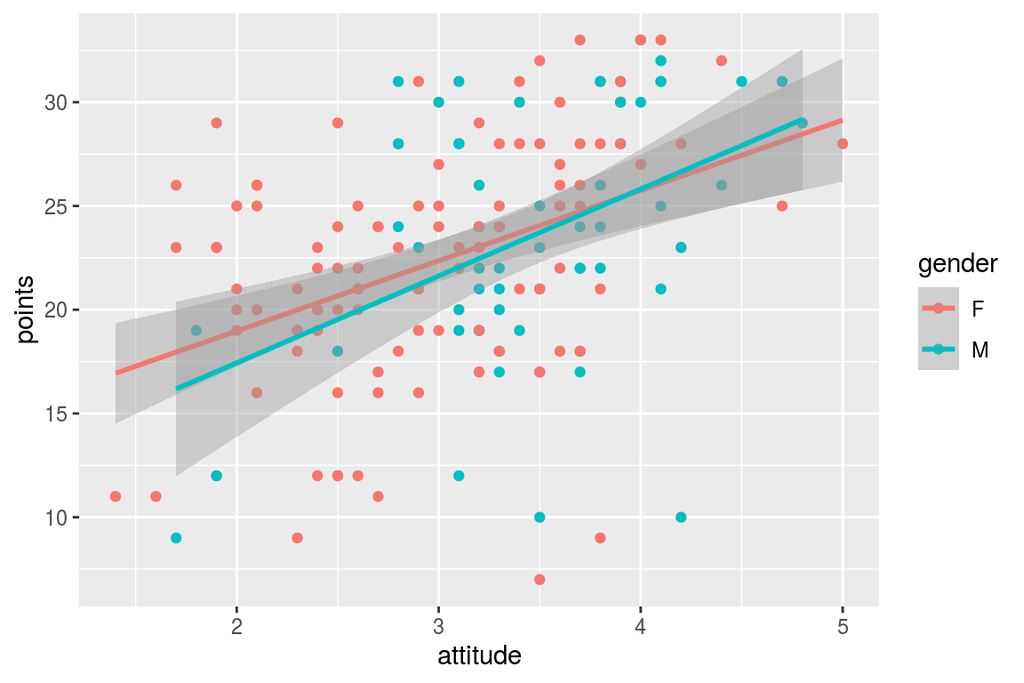

```r
library(ggplot2)
# plotting the two variables against each other with aesthetic mapping
p1 <- ggplot(students2014, aes(x = attitude, y = points, col=gender))

# using points for visualization
p2 <- p1 + geom_point()

# add a regression line and plot
p3 <- p2 + geom_smooth(method = "lm")
p3
```

### 5. Diagnostics plot

The Residuals vs. Fitted Values plot shows that the errors are quite normally distributed both above and under the 0-line, which is a good sine for our model.

The QQ plot explains the behaviour for most of inner quantiles and only diverges from the line in the outer quantiles.

The residuals vs. Leverage plot can show us if some points have too much leverage (outliers). In this case there is no outlier visible that completely changes the trend of the curve.

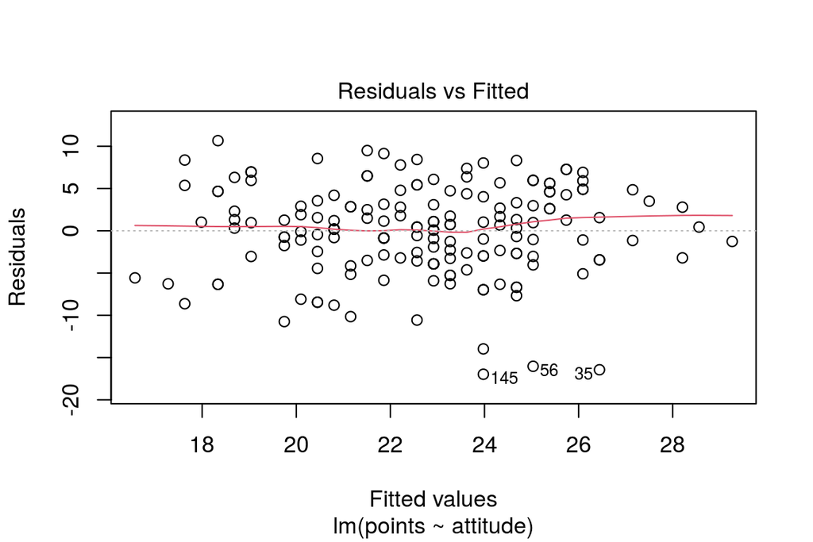

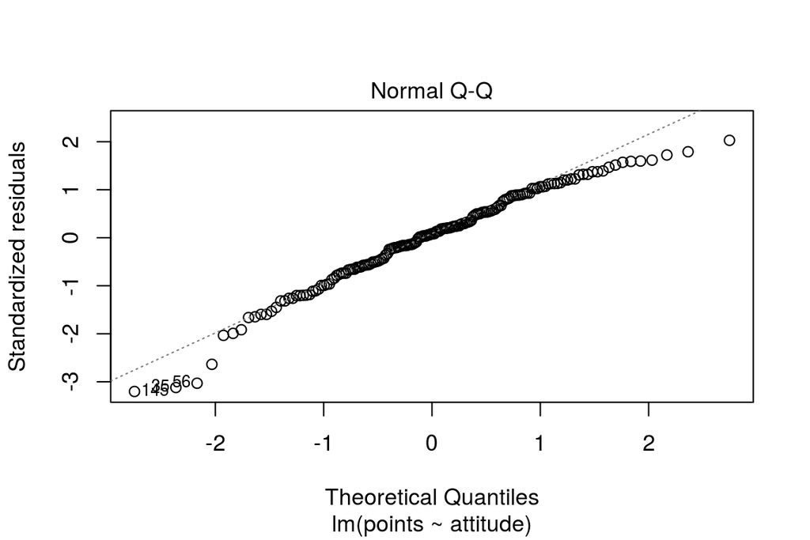

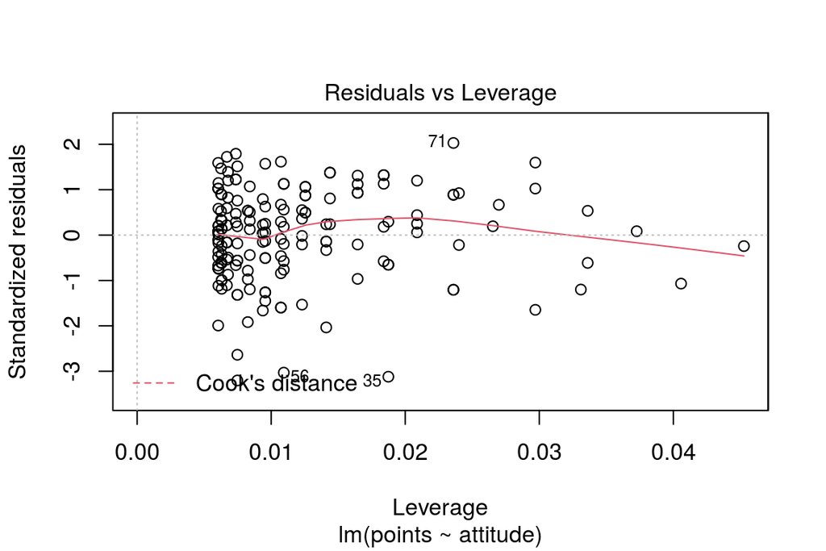

```r
#par(mfrow = c(2,2)) #To put the images in the same figures. However, I prefer them a bit bigger right now.
plot(my_model3, which=c(1,2,5))
```

# Chapter 3: Logistic Regression

## Data wrangling

The data wrangling part is performed in the R-script *create_alc.R* in the data folder and the created dataset is saved as a .csv file (‘alc.csv’) in the data folder.

## Data analysis

### 2. Reading the data and description of the dataset

The dataset we want to look at is a joined dataset from two datasets obtained from the following website: https://archive.ics.uci.edu/ml/datasets/Student+Performance , where it is also further described. It studies the performance of secondary education students of two Portuguese schools in mathematics and portuguese. The data sets content are answers of the students to different questions, which concern different areas of working and personal life, social background, circumstance etc.

Here, in our analysis, we will in particular look at the alcohol consumption and its relation to other variables.

To start the data analysis part, we include the library *dplyr* (`library(dplyr)`) and read in the dataset.

```r
library(dplyr)
```

```r
alc <- read.csv("./data/alc.csv")
```

To get an overview on the dataset, let’s print out the names of the variables and get the dimension values. The meaning of the values can be found on the above-mentioned website.

```r
colnames(alc)
```

```
##  [1] "X"          "school"     "sex"        "age"        "address"
##  [6] "famsize"    "Pstatus"    "Medu"       "Fedu"       "Mjob"
## [11] "Fjob"       "reason"     "nursery"    "internet"   "guardian"
## [16] "traveltime" "studytime"  "failures"   "schoolsup"  "famsup"
## [21] "paid"       "activities" "higher"     "romantic"   "famrel"
## [26] "freetime"   "goout"      "Dalc"       "Walc"       "health"
## [31] "absences"   "G1"         "G2"         "G3"         "alc_use"
## [36] "high_use"
```

```r
dim(alc)
```

```
## [1] 382  36
```

In total, we have 382 observations and 36 variables in the joined alc dataset.

### 3. Relation of different values to high/low alcohol consumption

Choose 4 interesting variables from the data and formulate hypothesis towards their relationship with alcohol consumption

**Hypothesis 1**: *sex*: There is a statistical difference concerning sex: Male students are more likely to have a high alcohol consumption than female students.

**Hypothesis 2** *failure*: The number of past class failures has a relation to alcohol consumption (more failures leading to more alcohol consumption).

**Hypothesis 3** *famrel*: Good family relationships make high alcohol consume less likely.

**Hypothesis 4** *goout*: The frequency of going out with friends will affect the alcohol consumption.

### 4. Numerical and graphical exploration of chosen variables

With `gather()` and `gplot()` one can first get an overview bar plot for each variable.

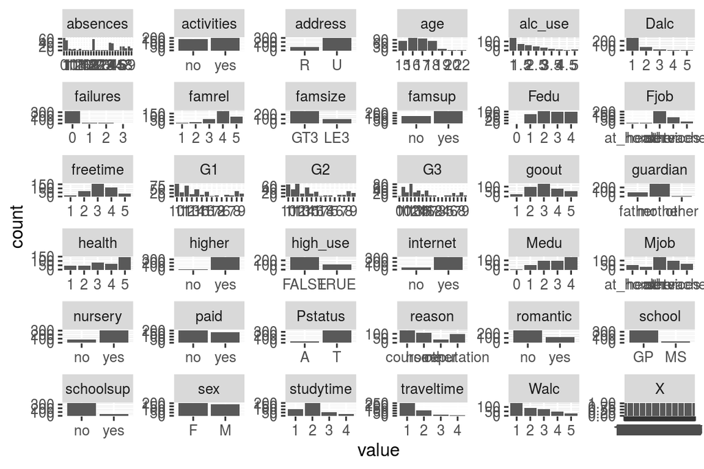

```r
library(tidyr); library(dplyr); library(ggplot2)
# draw a bar plot of each variable
gather(alc) %>% ggplot(aes(value)) + facet_wrap("key", scales = "free") + geom_bar()
```

Now we can continue by looking at the values interesting for the hypotheses stated above.

**Hypothesis 1: gender and alcoholic consumption**

```r
alc %>% group_by(sex, high_use) %>% summarise(count=n())
```

```
## # A tibble: 4 x 3
## # Groups:   sex [2]
##   sex   high_use count
##   <chr> <lgl>    <int>
## 1 F     FALSE      156
## 2 F     TRUE        42
## 3 M     FALSE      112
## 4 M     TRUE        72
```

The cross-tabulation is supporting **Hypothesis 1**. Whereas 21.2121212% of the female students mention a high alcohol consumption, 39.1304348% of the male students have mentioned a high use, which is almost the double value. To look at this graphically, let’s look at a bar plot.

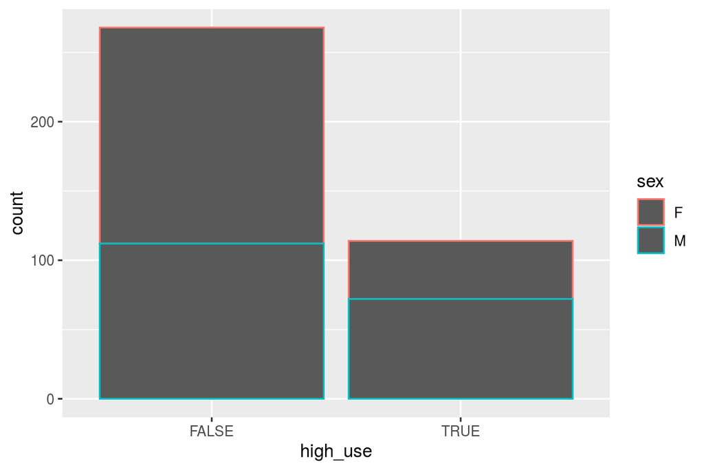

```r
library(ggplot2)
g2 <- ggplot(alc, aes(x = high_use, col=sex))
g2 + geom_bar()
```

The bar plot shows quite clearly, that the difference between high-use and no high-use are quite different for male and female students.

**Hypothesis 2 - failures**: Let’s now investigate if one can see a clear relation between the failures and the alcohol consumption.

```r
alc %>% group_by(high_use) %>% summarise(count=n())
```

```
## # A tibble: 2 x 2
##   high_use count
##   <lgl>    <int>
## 1 FALSE      268
## 2 TRUE       114
```

```r
alc %>% group_by(failures) %>% summarise(count=n())
```

```
## # A tibble: 4 x 2
##   failures count
##      <int> <int>
## 1        0   334
## 2        1    24
## 3        2    19
## 4        3     5
```

```r
alc %>% group_by(high_use, failures) %>% summarise(count=n())
```

```
## # A tibble: 8 x 3
## # Groups:   high_use [2]
##   high_use failures count
##   <lgl>       <int> <int>
## 1 FALSE           0   244
## 2 FALSE           1    12
## 3 FALSE           2    10
## 4 FALSE           3     2
## 5 TRUE            0    90
## 6 TRUE            1    12
## 7 TRUE            2     9
## 8 TRUE            3     3
```

```r
alc %>% group_by(high_use, failures>0) %>% summarise(count=n())
```

```
## # A tibble: 4 x 3
## # Groups:   high_use [2]
##   high_use `failures > 0` count
##   <lgl>    <lgl>          <int>
## 1 FALSE    FALSE            244
## 2 FALSE    TRUE              24
## 3 TRUE     FALSE             90
## 4 TRUE     TRUE              24
```

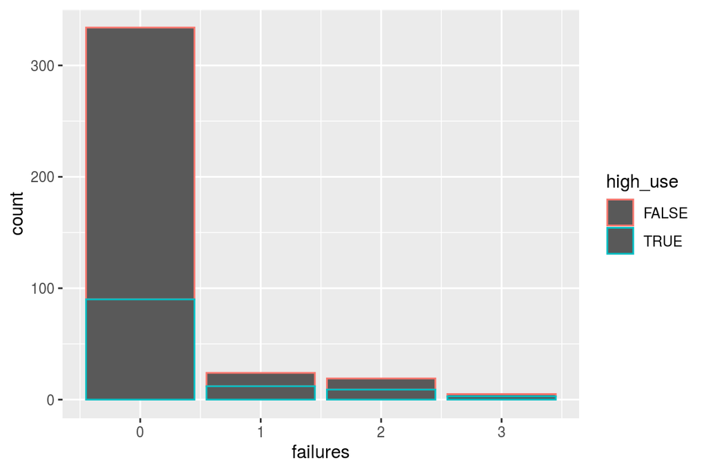

```r
g3 <- ggplot(alc, aes(x=failures, col=high_use))
g3 + geom_bar()
```

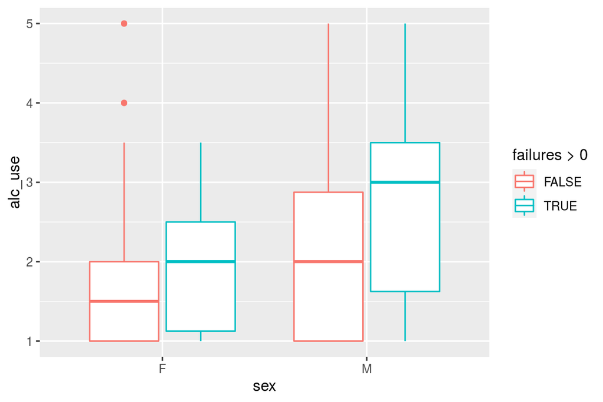

```r
g4 <- ggplot(alc, aes(x = sex, y = alc_use, col=failures>0))
g4 + geom_boxplot()
```

Looking at the bar plot, one might at least come to the conclusion, that having experienced no failure makes it less likely to become addicted to high alcoholic consumption. However, the sample for having a failure is much less than for having none. It might make more sense to combine the numbers for failures > 1 together. Now, a box plot gives a nice visualisation of how having experienced at least 1 failure can impact the alcoholic consumption. Again, the impact seems to be much higher for the male students.

**Hypothesis 3 - Family**:

```r
alc %>% group_by(famrel,high_use) %>% summarise(count=n())
```

```
## # A tibble: 10 x 3
## # Groups:   famrel [5]
##    famrel high_use count
##     <int> <lgl>    <int>
##  1      1 FALSE        6
##  2      1 TRUE         2
##  3      2 FALSE       10
##  4      2 TRUE         9
##  5      3 FALSE       39
##  6      3 TRUE        25
##  7      4 FALSE      135
##  8      4 TRUE        54
##  9      5 FALSE       78
## 10      5 TRUE        24
```

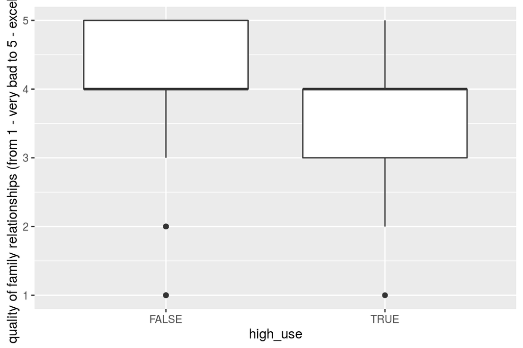

```r
g5 <- ggplot(alc, aes(x = high_use, y = famrel))
g5 + geom_boxplot() + ylab("quality of family relationships (from 1 - very bad to 5 - excellent)")
```

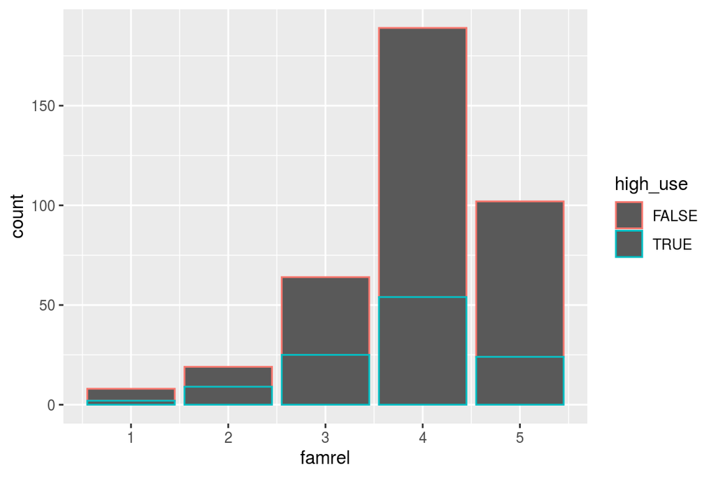

```r
g6 <- ggplot(alc, aes(x=famrel, col=high_use))
g6 + geom_bar()
```

**Hypothesis 4 - going out**

```r
alc %>% group_by(goout,high_use) %>% summarise(count=n())
```

```
## # A tibble: 10 x 3
## # Groups:   goout [5]
##    goout high_use count
##    <int> <lgl>    <int>
##  1     1 FALSE       19
##  2     1 TRUE         3
##  3     2 FALSE       84
##  4     2 TRUE        16
##  5     3 FALSE      103
##  6     3 TRUE        23
##  7     4 FALSE       41
##  8     4 TRUE        40
##  9     5 FALSE       21
## 10     5 TRUE        32
```

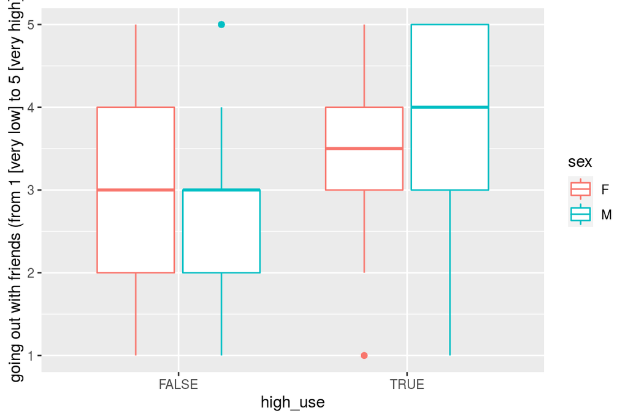

```r
g7 <- ggplot(alc, aes(x = high_use, y = goout, col=sex))
g7 + geom_boxplot() + ylab("going out with friends (from 1 [very low] to 5 [very high]")
```

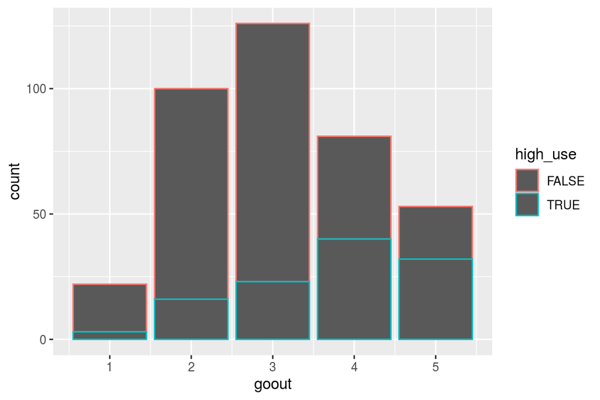

```r
g8 <- ggplot(alc, aes(x=goout, col=high_use))
g8 + geom_bar()
```

Again, the numeric cross tabulations as well as the plots are supporting the hypothesis. Going out with friends more often (higher value) seems to have an impact on the alcohol consumption.

### 5. Logistic regression

```r
# find the model with glm()
m <- glm(high_use ~ sex + failures + famrel + goout, data = alc, family = "binomial")
summary(m)
```

```
##
## Call:
## glm(formula = high_use ~ sex + failures + famrel + goout, family = "binomial",
##     data = alc)
##
## Deviance Residuals:
##     Min       1Q   Median       3Q      Max
## -1.6492  -0.7464  -0.5207   0.8642   2.4194
##
## Coefficients:
##             Estimate Std. Error z value Pr(>|z|)
## (Intercept)  -2.3922     0.6415  -3.729 0.000192 ***
## sexM          0.8976     0.2530   3.548 0.000388 ***
## failures      0.3339     0.2034   1.641 0.100696
## famrel       -0.3971     0.1390  -2.857 0.004281 **
## goout         0.7751     0.1217   6.367 1.93e-10 ***
## ---
## Signif. codes:  0 '***' 0.001 '**' 0.01 '*' 0.05 '.' 0.1 ' ' 1
##
## (Dispersion parameter for binomial family taken to be 1)
##
##     Null deviance: 465.68  on 381  degrees of freedom
## Residual deviance: 391.08  on 377  degrees of freedom
## AIC: 401.08
##
## Number of Fisher Scoring iterations: 4
```

The model summary shows a high significance for the correlation to *sexM* and *goout*, a medium significance for *famrel* und no signifant value for *failure*. One could fit the model again, dropping at least the *failure* variable. But first let’s study the odds ratios (OR).

```r
coef(m)
```

```
## (Intercept)        sexM    failures      famrel       goout
##  -2.3922069   0.8976484   0.3338923  -0.3971296   0.7751449
```

```r
# compute odds ratios (OR)
OR <- coef(m) %>% exp

# compute confidence intervals (CI)
CI <- confint(m) %>% exp
# print out the odds ratios with their confidence intervals
cbind(OR, CI)
```

```
##                     OR      2.5 %    97.5 %
## (Intercept) 0.09142769 0.02506625 0.3124735
## sexM        2.45382585 1.50205707 4.0576659
## failures    1.39639281 0.93864152 2.0963627
## famrel      0.67224693 0.51012773 0.8814055
## goout       2.17090677 1.72124671 2.7771652
```

The odds ratios can tell us if having a certain property (e.g. being male, going out often) can be positively or negatively associated with the logical value looked at (here high alcohol consumption). If the OR is > 1, it means it is positively associated, with < 1 it is negatively associated.

The male sex variable has the strongest relationship to the binary target variable, with an odds ratio of +2.45 - that means that the probability for a male student having high alcohol consumption is about 2.5 higher than for a female student. “going out” is also positively associated with high alcohol consumption, wheres “family relation” has a negative relation (high quality of family relation leading more likely to low alcohol consumption). These OR thus support the above-mentioned hypotheses.

### 6. Predictive power of Model

As *failures* didn’t have a significant relationship according to my logistic regression model, I will drop this variable and fit the model again, print out the summary and calculate the OR and Confidence levels:

```r
m2 <- glm(high_use ~ sex + famrel + goout, data = alc, family = "binomial")
summary(m2)
```

```
##
## Call:
## glm(formula = high_use ~ sex + famrel + goout, family = "binomial",
##     data = alc)
##
## Deviance Residuals:
##     Min       1Q   Median       3Q      Max
## -1.5836  -0.7707  -0.5316   0.8198   2.5474
##
## Coefficients:
##             Estimate Std. Error z value Pr(>|z|)
## (Intercept)  -2.3550     0.6414  -3.672 0.000241 ***
## sexM          0.9342     0.2514   3.716 0.000202 ***
## famrel       -0.4118     0.1387  -2.969 0.002989 **
## goout         0.7971     0.1214   6.565  5.2e-11 ***
## ---
## Signif. codes:  0 '***' 0.001 '**' 0.01 '*' 0.05 '.' 0.1 ' ' 1
##
## (Dispersion parameter for binomial family taken to be 1)
##
##     Null deviance: 465.68  on 381  degrees of freedom
## Residual deviance: 393.80  on 378  degrees of freedom
## AIC: 401.8
##
## Number of Fisher Scoring iterations: 4
```

```r
coef(m2)
```

```
## (Intercept)        sexM      famrel       goout
##  -2.3549669   0.9341541  -0.4117517   0.7971166
```

```r
OR <- coef(m2) %>% exp
CI <- confint(m2) %>% exp
cbind(OR, CI)
```

```
##                     OR      2.5 %    97.5 %
## (Intercept) 0.09489664 0.02602013 0.3241397
## sexM        2.54505957 1.56349803 4.1969640
## famrel      0.66248876 0.50299888 0.8679153
## goout       2.21913298 1.76086023 2.8372779
```

As a next step let’s check the predictive power of the new model, adding the new columns *probability* and *predictions* to the *alc* dataset. *probablities* will be calculated by using the `predict()` function on the model and *predictions* will defined as TRUE if the probability is higher than 50%.

```r
probabilities <- predict(m2, type = "response")
alc <- mutate(alc, probability = probabilities)
alc <- mutate(alc, prediction = probabilities > 0.5)
```

```r
select(alc, sex, famrel, goout,  high_use, probability, prediction) %>% tail(10)
```

```
##     sex famrel goout high_use probability prediction
## 373   M      4     2    FALSE  0.18639810      FALSE
## 374   M      5     3     TRUE  0.25195331      FALSE
## 375   F      5     3    FALSE  0.11687357      FALSE
## 376   F      4     3    FALSE  0.16650200      FALSE
## 377   F      5     2    FALSE  0.05627990      FALSE
## 378   F      4     4    FALSE  0.30714360      FALSE
## 379   F      2     2    FALSE  0.17019623      FALSE
## 380   F      1     1    FALSE  0.12243164      FALSE
## 381   M      2     5     TRUE  0.85084788       TRUE
## 382   M      4     1     TRUE  0.09357856      FALSE
```

```r
table(high_use = alc$high_use, prediction = alc$prediction)
```

```
##         prediction
## high_use FALSE TRUE
##    FALSE   250   18
##    TRUE     63   51
```

To graphically visualize the actual values and the predictions, we can draw a plot of ‘high use’ vs. ‘probability’.

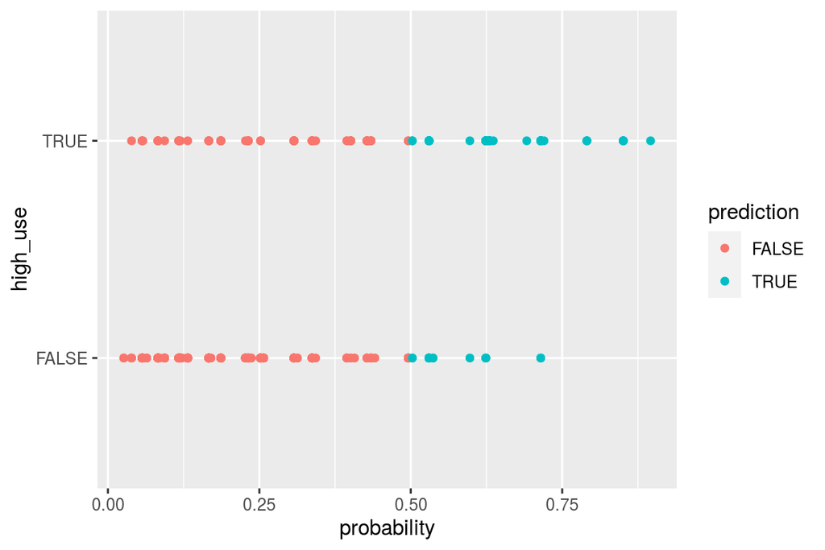

```r
g <- ggplot(alc, aes(x = probability, y = high_use, col=prediction))
g + geom_point()
```

Furthermore, we can do another cross-tab of predictions vs. actual values, printing out the fractions instead and adding margins.

```r
table(high_use = alc$high_use, prediction = alc$prediction) %>% prop.table() %>% addmargins()
```

```
##         prediction
## high_use      FALSE       TRUE        Sum
##    FALSE 0.65445026 0.04712042 0.70157068
##    TRUE  0.16492147 0.13350785 0.29842932
##    Sum   0.81937173 0.18062827 1.00000000
```

**Accuracy of the model** The proportion of inaccurately classified individuals (training error) can be calculated by taking the values from the confusion matrix: (18+63)/(250+18+63+51) = 0.21. We will get the same value by defiing a loss function as below:

```r
# define a loss function (mean prediction error)
loss_func <- function(class, prob) {
  n_wrong <- abs(class - prob) > 0.5
  mean(n_wrong)
}

# call loss_func to compute the average number of wrong predictions in the (training) data
loss_func(class = alc$high_use, prob = alc$probability)
```

```
## [1] 0.2120419
```

The loss function gives us a value of about 0.21 (as also calculated before), meaning that about 21% of the predictions will be wrong. This value is better than the value in the DataCamp example (about 26%), making this model slightly better.

### 7. Bonus: 10-fold cross-validation

To study the test set performance of the model one can use K-fold cross-validation. Here, we will try out 10-fold cross-validation, making use of the loss function defined above.

```r
library(boot)
cv <- cv.glm(data = alc, cost = loss_func, glmfit = m2, K=10)
cv$delta[1]
```

```
## [1] 0.2277487
```

The cv.glm function of the library `boot` can be used for this and `K=10` defines the number of subsets we are doing the cross-validation on. The `delta` attribute stores the error value. It gives an error of about 0.23 which is better than the 0.26 error of the DataCamp model. Thus, it has a bit better performance.

(more chapters to be added similarly as we proceed with the course!)